# Marketing Analytics & Social Media Intelligence (337090)

#### 4.5.)c.)

Display the ROC-curve for the two models and comment on the findings.

##### Boosted Decision Tree

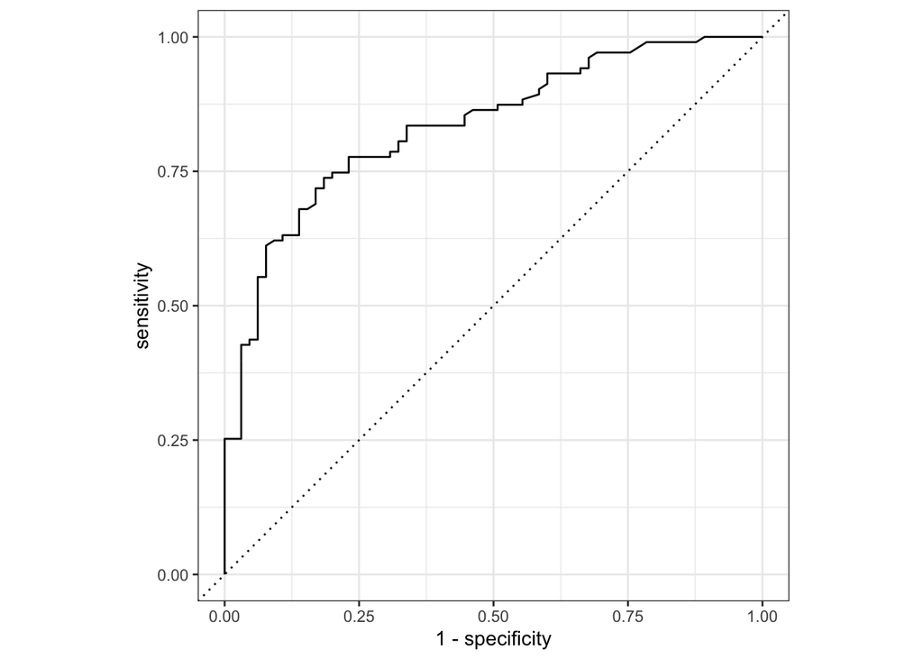

```r
bdt_prediction %>%
  roc_curve(truth=gender_test$Gender, .pred_female) %>%
  autoplot()
```

```r
bdt_prediction %>%
  roc_auc(truth=gender_test$Gender, .pred_female)
```

```
## # A tibble: 1 x 3
##   .metric .estimator .estimate
##   <chr>   <chr>          <dbl>
## 1 roc_auc binary         0.834
```

##### Logistic Regression

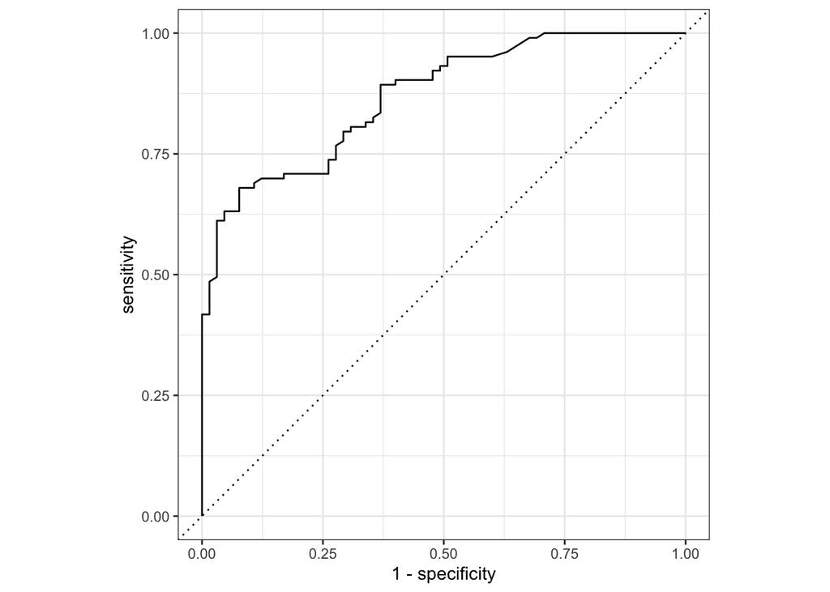

```r
gender_pred_logreg %>%
  roc_curve(truth=gender_test$Gender, .pred_female) %>%
  autoplot()
```

```r
gender_pred_logreg %>%
  roc_auc(truth=gender_test$Gender, .pred_female)
```

```
## # A tibble: 1 x 3
##   .metric .estimator .estimate
##   <chr>   <chr>          <dbl>
## 1 roc_auc binary         0.868
```

Wenn wir die beiden Kurven vergleichen, fällt auf, dass die ROC Kurve der Log Reg besser abschneidet, weil sie steiler nach oben geht und dadurch eine höhere Trefferquote hat. Außerdem ist ihr Area under Curve (AUC) Wert etwas besser (0.87) -> je näher der Wert an der 1 desto besser.